### Описание данных

Data from [the-numbers.com](https://www.the-numbers.com/)

| Header | Description |
| --- | --- |
| `release_date` | month-day-year |
| `movie` | Movie title |
| `production_budget` | Money spent to create the film |
| `domestic_gross` | Gross revenue from USA |
| `worldwide_gross` | Gross worldwide revenue |
| `distributor` | The distribution company |
| `mpaa_rating` | Appropriate age rating by the US-based rating agency |
| `genre` | Film category |

### Подготовка данных

Импорт исходных данных

```r
movie_profit_raw <- read_csv("movie_profit.csv")
```

Приводим исходные данные к аккуратному виду

```r
movie_profit <- movie_profit_raw %>%
  # избавимся от первого столбца потому что это не информативный столбец
  select(-X1) %>%
  # дата сохранена как текст, распарсим её для корректного отображения
  mutate(release_date = as.Date(parse_date_time(release_date, "%m!/%d/%Y"))) %>%
  # будем изучать только фильмы, вышедшие до начала 2018 года
  filter(release_date < "2018-01-01") %>%
  arrange(desc(row_number())) %>%
  distinct(movie, release_date, .keep_all = TRUE) %>%
  # предположим, что самые большие бюджеты на производство сконцентрированы в руках нескольких компаний, допустим 6 (в ходе анализа стало понятно что лучше пять)
  mutate(distributor = fct_lump(distributor, n = 5)) %>%
  # отфильтруем фильмы с нулевыми кассовыми сборами, вероятно они не вышли
  filter(worldwide_gross > 0) %>%
  # добавим коэффициент окупаемости, объясняется ниже и декады
  mutate(profit_ratio = worldwide_gross / production_budget,
         decade = 10 * floor(year(release_date) / 10))
```

### Сколько денег затрачивается на производство?

Посмотрим сколько обычно тратится денег на производство одного фильма

```r
# для начала посмотрим сколько фильмов производят компании.
movie_profit %>%
  count(distributor, sort = TRUE)
```

```
## # A tibble: 7 x 2
##   distributor            n
##   <fct>              <int>
## 1 Other               1737
## 2 Warner Bros.         360
## 3 Sony Pictures        332
## 4 Universal            299
## 5 20th Century Fox     279
## 6 Paramount Pictures   261
## 7 <NA>                  42
```

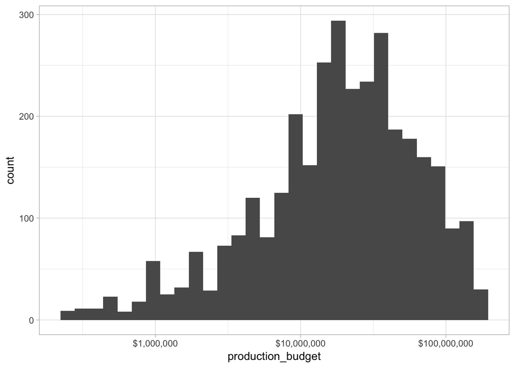

```r
# шесть компаний производят столько же фильмов, сколько все оставшиеся компании

movie_profit %>%
  ggplot(aes(production_budget)) +
  geom_histogram() +
  scale_x_log10(labels = dollar_format())
```

Построим ящики с усами, для наглядного отображения

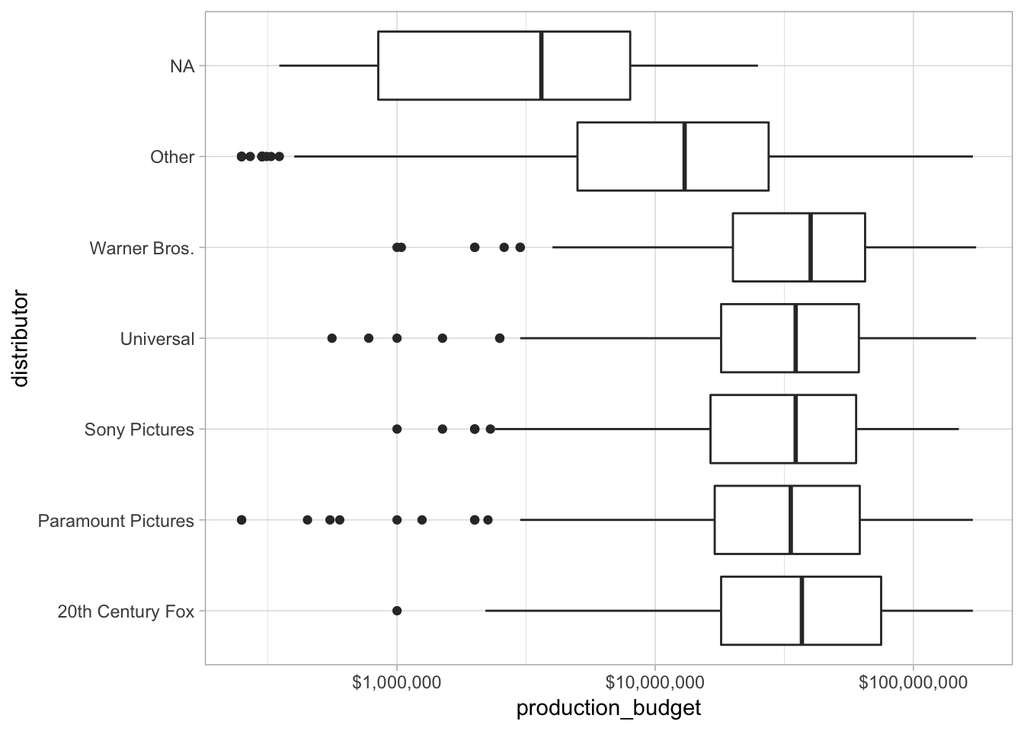

```r
movie_profit %>%
  ggplot(aes(distributor, production_budget)) +
  geom_boxplot() +
  scale_y_log10(labels = dollar_format()) +
  coord_flip()
```

Посмотрим как распределяются вознаграждения за фильм

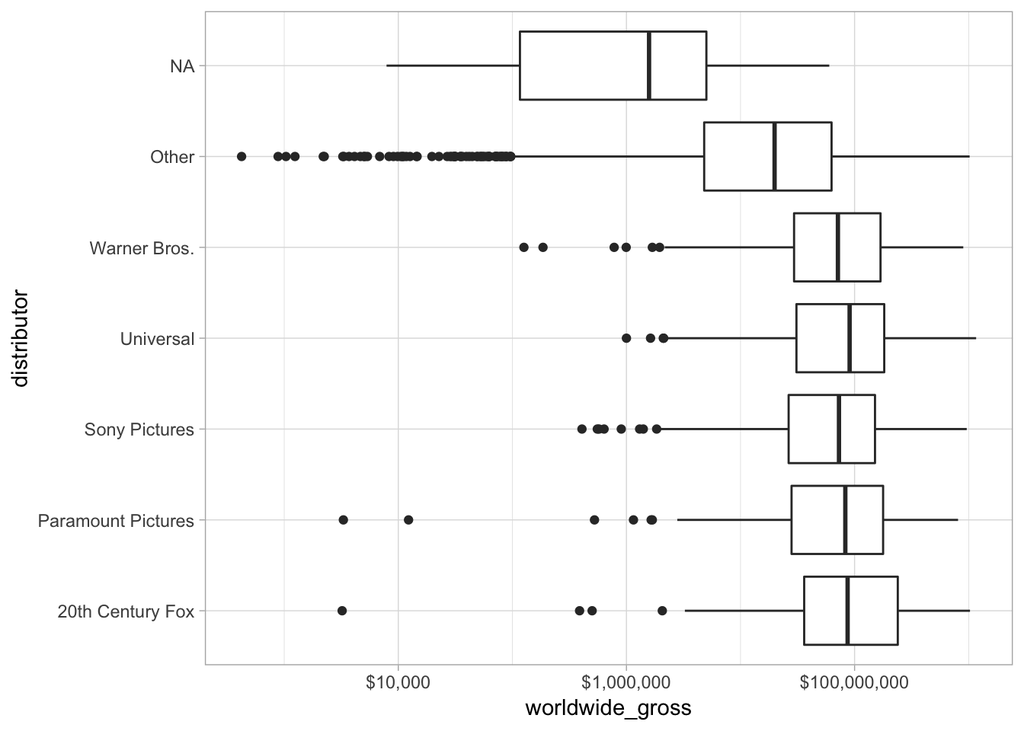

```r
movie_profit %>%
  ggplot(aes(distributor, worldwide_gross)) +
  geom_boxplot() +
  scale_y_log10(labels = dollar_format()) +
  coord_flip()
```

В общем картина похожа на затраты.

### Какие жанры приносят больше всего прибыли

Какие вообще есть жанры?

```r
movie_profit %>%
  count(genre, sort = TRUE)
```

```
## # A tibble: 5 x 2
##   genre         n
##   <chr>     <int>
## 1 Drama      1209
## 2 Comedy      798
## 3 Action      547
## 4 Adventure   467
## 5 Horror      289
```

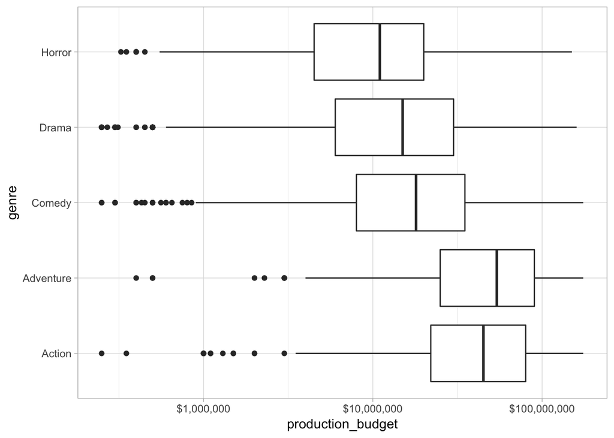

```r
movie_profit %>%
  ggplot(aes(genre, production_budget)) +
  geom_boxplot() +
  scale_y_log10(labels = dollar_format()) +
  coord_flip()
```

Заметны различия, перераспределим жанры по увеличению бюджета

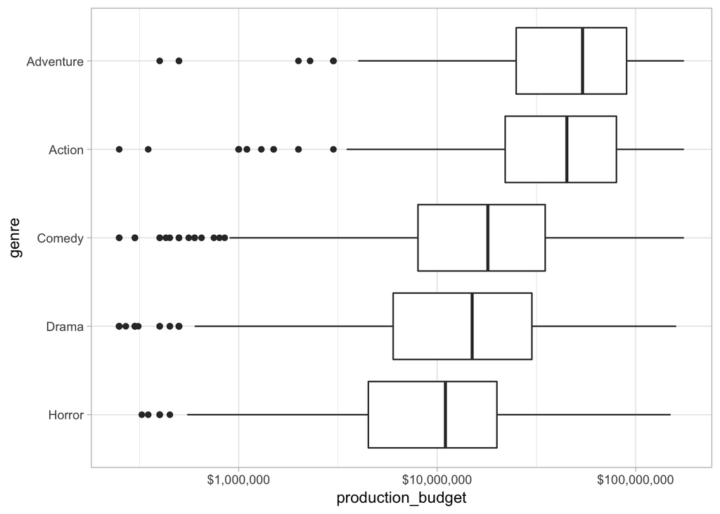

```r
movie_profit %>%
  mutate(genre = fct_reorder(genre, production_budget)) %>%
  ggplot(aes(genre, production_budget)) +
  geom_boxplot() +
  scale_y_log10(labels = dollar_format()) +
  coord_flip()
```

Самые большие затрыты на приключения, самые низкие на ужастики.

Какой наиболее встречаемый бюджет за всё время?

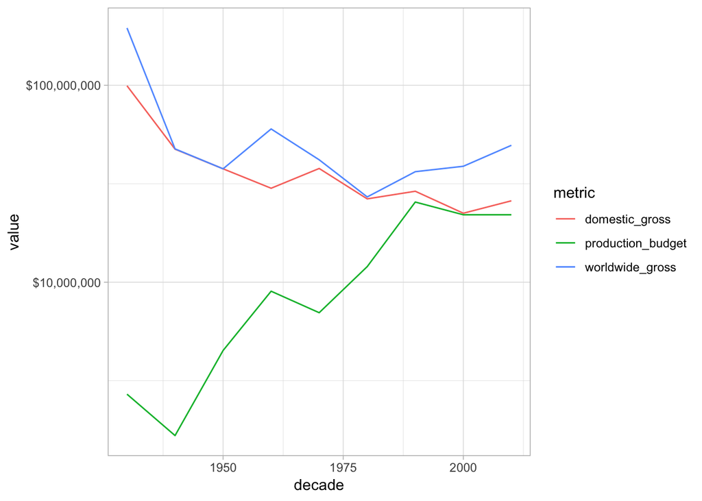

```r
movie_profit %>%
  # сгруппируем фильмы по декадам
  mutate(decade = 10 * floor(year(release_date) / 10)) %>%
  group_by(decade) %>%
  # посмотрим медианные значения по всем числовым характеристикам
  summarize_at(vars(production_budget:worldwide_gross), median, na.rm = TRUE) %>%
  # соберём все данные в таблицу, для удобного отображения
  gather(metric, value, -decade) %>%
  # посмотрим как декада к дакаде менялись затраты и окупаемость фильмов
  ggplot(aes(decade, value, color = metric)) +
  geom_line() +
  scale_y_log10(labels = dollar_format())
```

Посмотрим сколько компании тратят на производство каждого представленного жанра. Для этого рассмотрим ящики с усами по панелям, в зависимости от производителя

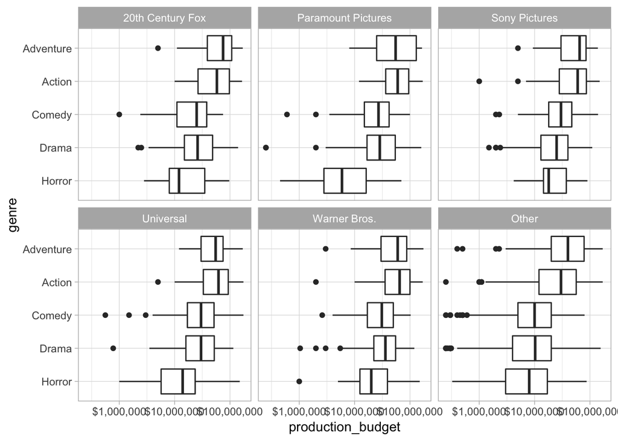

```r
movie_profit %>%
  mutate(genre = fct_reorder(genre, production_budget)) %>%
  filter(!is.na(distributor)) %>%
  ggplot(aes(genre, production_budget)) +
  geom_boxplot() +
  scale_y_log10(labels = dollar_format()) +
  coord_flip() +
  facet_wrap(~ distributor)
```

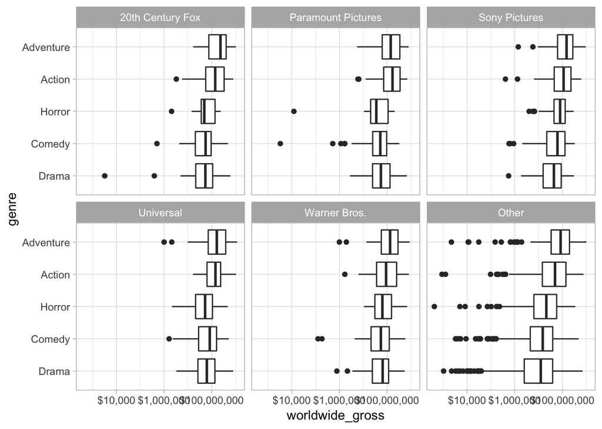

```r
movie_profit %>%
  mutate(genre = fct_reorder(genre, worldwide_gross)) %>%
  filter(!is.na(distributor)) %>%
  ggplot(aes(genre, worldwide_gross)) +
  geom_boxplot() +
  scale_y_log10(labels = dollar_format()) +
  coord_flip() +
  facet_wrap(~ distributor)
```

У всех компаний примерно стабильные доходы от выпуска фильма. Кроме “остальных” компаний. Длинный хвост и большое количество выбросов, говорит о том что многие фильмы не приносят ожидаемых доходов.

### Какие жанры имеют наибольшее вознаграждение

Посмотрим отношение кассовых международных сборов к производству фильмов. Для этого мы введём коэффициент окупаемости, который показываеты отношение денег полученных от продаж к затраченным на производство фильма. Чем дальше от единицы, тем большая окупаемость. Чем меньше единицы, тем провальнее были кассовые сборы.

```r
movie_profit %>%
  mutate(profit_ratio = worldwide_gross / production_budget) %>%
  arrange(desc(profit_ratio))
```

```
## # A tibble: 3,310 x 10
##    release_date movie production_budg… domestic_gross worldwide_gross
##    <date>       <chr>            <dbl>          <dbl>           <dbl>
##  1 2009-09-25   Para…           450000      107918810       194183034
##  2 1999-07-14   The …           600000      140539099       248300000
##  3 1942-08-13   Bambi           858000      102797000       268000000
##  4 1976-11-21   Rocky          1000000      117235147       225000000
##  5 1978-10-17   Hall…           325000       47000000        70000000
##  6 1973-08-11   Amer…           777000      115000000       140000000
##  7 2004-06-11   Napo…           400000       44540956        46122713
##  8 1980-05-09   Frid…           550000       39754601        59754601
##  9 2012-01-06   The …          1000000       53262945       101759490
## 10 1939-12-15   Gone…          3900000      198680470       390525192
## # ... with 3,300 more rows, and 5 more variables: distributor <fct>,
## #   mpaa_rating <chr>, genre <chr>, profit_ratio <dbl>, decade <dbl>
```

Взглянем на распределение коэффициента

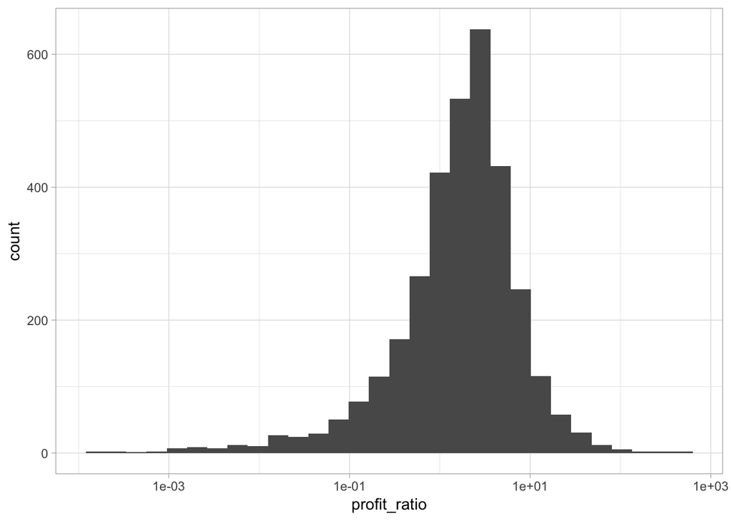

```r
movie_profit %>%
  mutate(profit_ratio = worldwide_gross / production_budget) %>%
  arrange(profit_ratio) %>%
  ggplot(aes(profit_ratio)) +
  geom_histogram() +
  scale_x_log10()
```

Очень близко к нормальному. Посмотрим, как меняется коэффициент в зависимости от жанра

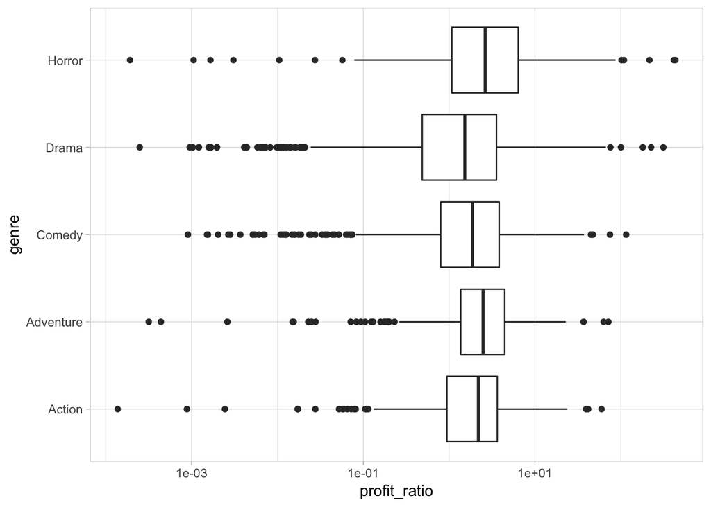

```r
movie_profit %>%
  mutate(profit_ratio = worldwide_gross / production_budget) %>%
  arrange(profit_ratio) %>%
  ggplot(aes(genre, profit_ratio)) +
  geom_boxplot() +
  scale_y_log10() +
  coord_flip()
```

Ящики показывают, что основная масса фильмов, укладываются между 0.1 и 10. Посмотрим какой средний коэффициент в зависимости от жанра

```r
movie_profit %>%
  mutate(profit_ratio = worldwide_gross / production_budget) %>%
  group_by(genre) %>%
  summarise(median_profit_ratio = median(profit_ratio)) %>%
  arrange(desc(median_profit_ratio))
```

```
## # A tibble: 5 x 2
##   genre     median_profit_ratio
##   <chr>                   <dbl>
## 1 Horror                   2.63
## 2 Adventure                2.49
## 3 Action                   2.19
## 4 Comedy                   1.87
## 5 Drama                    1.52
```

Покажем это же распределение при помощи столбиков

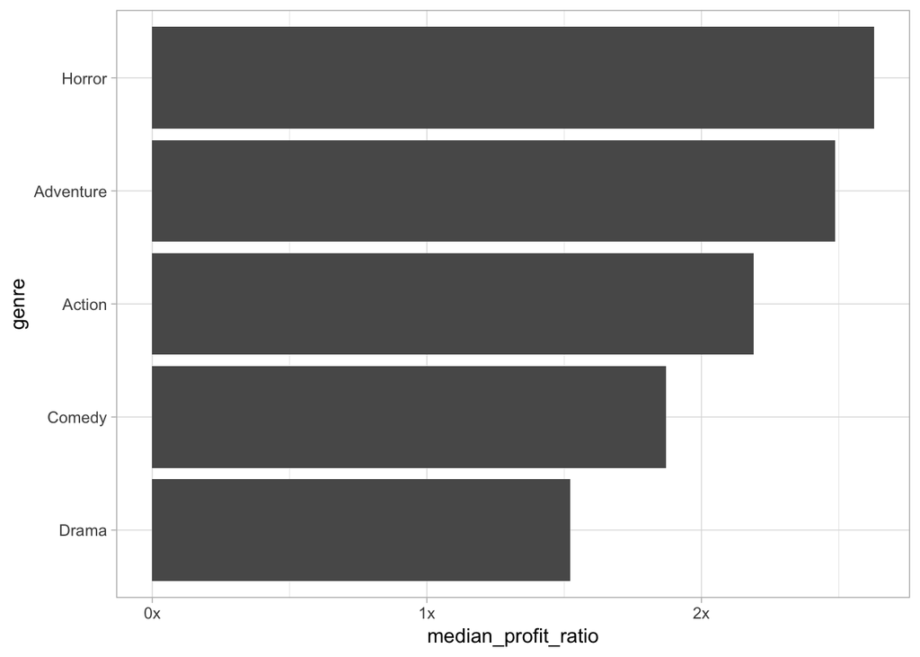

```r
movie_profit %>%
  mutate(profit_ratio = worldwide_gross / production_budget) %>%
  group_by(genre) %>%
  summarise(median_profit_ratio = median(profit_ratio)) %>%
  arrange(desc(median_profit_ratio)) %>%
  mutate(genre = fct_reorder(genre, median_profit_ratio)) %>%
  ggplot(aes(genre, median_profit_ratio)) +
  geom_col() +
  coord_flip() +
  scale_y_continuous(labels = function(x) paste0(x, "x")) # Для наглядности, поменяем подписи оси, на соответствующее кратное увеличение
```

Отличный показатель. Давайте теперь рассмотрим как менялся этот показатель год от года в разных жанрах

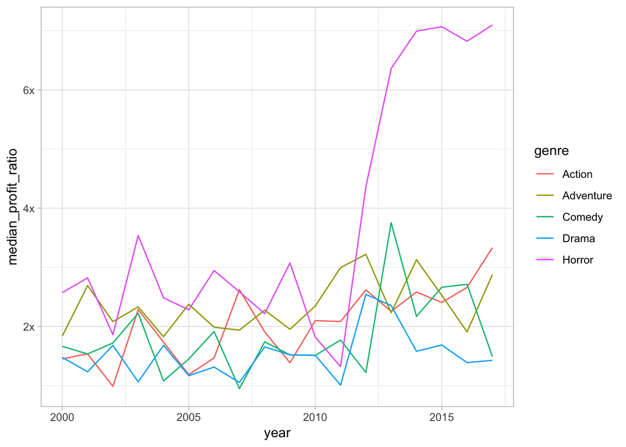

```r
movie_profit %>%
  group_by(genre, year = year(release_date)) %>%
  summarise(median_profit_ratio = median(profit_ratio),
            movies = n()) %>%
  ungroup() %>%
  filter(year >= 2000) %>%
  arrange(desc(median_profit_ratio)) %>%
  ggplot(aes(year, median_profit_ratio, color = genre)) +
  geom_line() +
  scale_y_continuous(labels = function(x) paste0(x, "x"))
```

Интересная история у фильмов ужасов — до примерно 2010 всё развивалось примерно как и в других жанрах. А потом произошёл необычный скачок.

Давайте посмотрим, какие фильмы ужасов стали наиболее прибыльными примерно в 2012 году

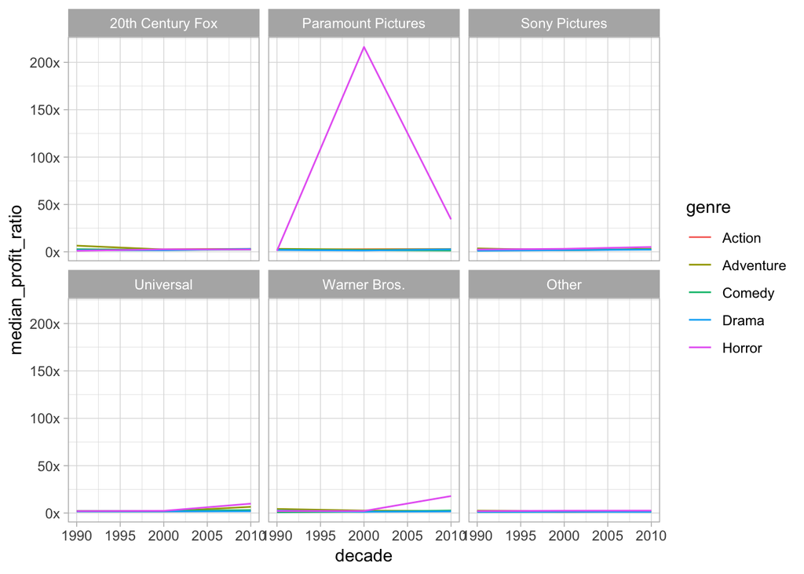

```r
movie_profit %>%
  group_by(genre, distributor, decade) %>%
  summarise(median_profit_ratio = median(profit_ratio),
            movies = n()) %>%
  ungroup() %>%
  filter(decade >= 1990,
         !is.na(distributor)) %>%
  arrange(desc(median_profit_ratio)) %>%
  ggplot(aes(decade, median_profit_ratio, color = genre)) +
  geom_line() +
  facet_wrap(~ distributor) +
  scale_y_continuous(labels = function(x) paste0(x, "x"))
```

Здесь отчётливо видно, что основной скачок в фильмах ужасов произвела кампания Парамаунт Пиктчерз. Поэтому ответом на изначальный вопрос будет — фильмы ужасов, которые снимала Парамаунт Пиктчерз в 2000-х годах

Но какие фильмы были самыми профитными, давайте взглянем

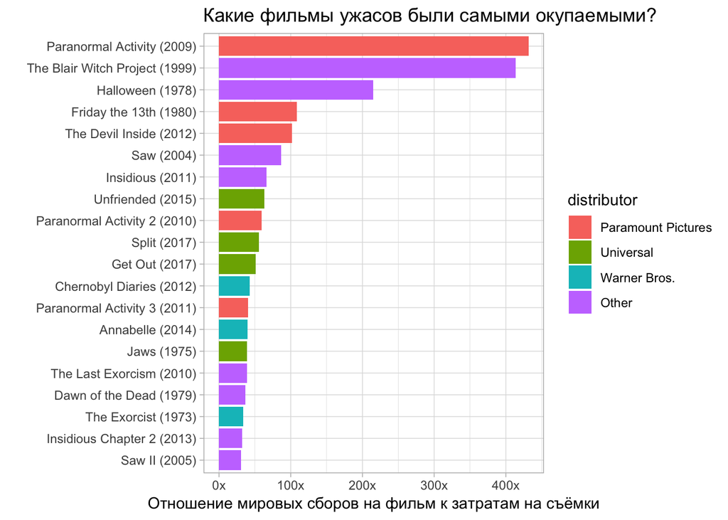

```r
horror <- movie_profit %>%
  filter(genre == "Horror") %>%
  arrange(desc(profit_ratio))

horror %>%
  head(20) %>%
  mutate(movie = paste0(movie, " (", year(release_date), ")"),
    movie = fct_reorder(movie, profit_ratio)) %>%
  ggplot(aes(movie, profit_ratio, fill = distributor)) +
  geom_col() +
  coord_flip() +
  labs(x = "",
       y = "Отношение мировых сборов на фильм к затратам на съёмки",
       title = "Какие фильмы ужасов были самыми окупаемыми?") +
    scale_y_continuous(labels = function(x) paste0(x, "x"))
```

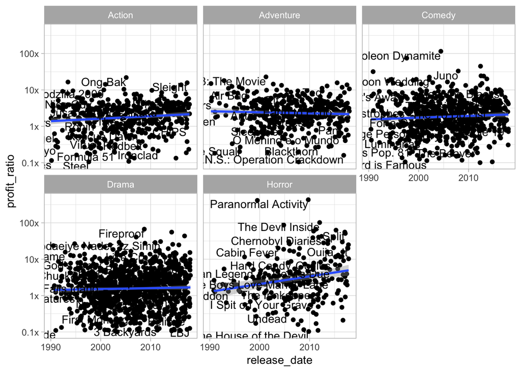

```r
movie_profit %>%
  filter(release_date >= "1990-01-01",
         profit_ratio >= 0.1) %>%
  ggplot(aes(release_date, profit_ratio)) +
  geom_point() +
  geom_smooth(method = "lm") +
  geom_text(aes(label = movie), vjust = 1, hjust = 1, check_overlap = TRUE) +
  scale_y_log10(labels = function(x) paste0(x, "x"), breaks = c(0.1, 1, 10, 100)) +
  facet_wrap(~ genre)
```

### Какие жанры чаще всего снимались за всё время

Что снимают год от года

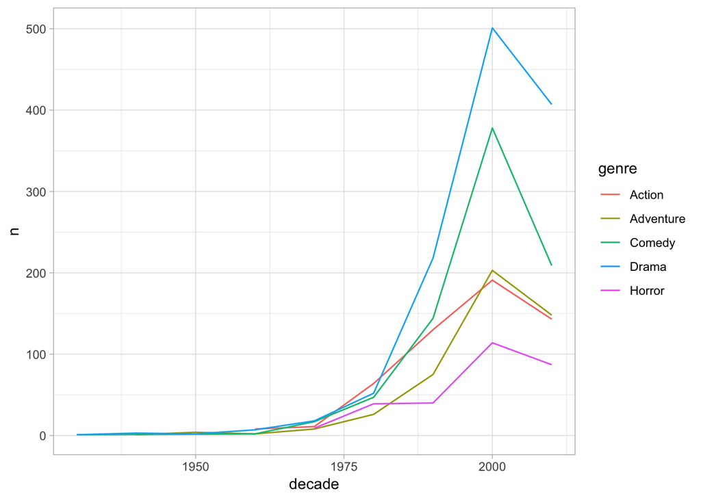

```r
movie_profit %>%
  count(decade, genre) %>%
  ggplot(aes(decade, n, color = genre)) +
  geom_line()
```

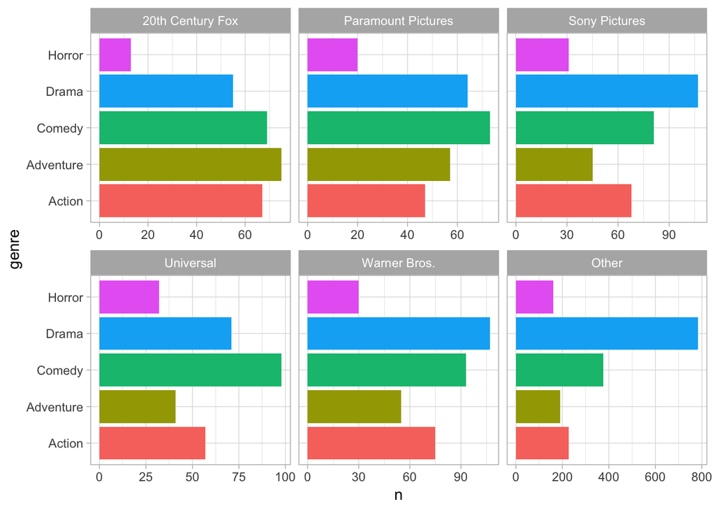

```r
movie_profit %>%
  filter(!is.na(distributor)) %>%
  count(distributor, genre) %>%
  ggplot(aes(genre, n, fill = genre)) +
  geom_col(show.legend = FALSE) +
  facet_wrap(~ distributor, scales = "free_x") +
  coord_flip()
```